# An Assessment of the NOAA Storm Database

Robert Muwanga

9/20/2021

# Nature events that affect economic and population health

## Synopsis

An analysis of the U.S. National Oceanic and Atmospheric Administration’s (NOAA) storm database was performed to get an understanding of which natural events have a big impact on the health of the United States’ population, and the greatest economic consequences across the country.

These results were generated from the [U.S. National Oceanic and Atmospheric Administration’s (NOAA) storm database](https://d396qusza40orc.cloudfront.net/repdata%2Fdata%2FStormData.csv.bz2). Details on this dataset can be acquired by visiting the [National Weather Service Storm Data Documentation](https://d396qusza40orc.cloudfront.net/repdata%2Fpeer2_doc%2Fpd01016005curr.pdf) and the [National Climatic Data Center Storm Events FAQ](https://d396qusza40orc.cloudfront.net/repdata%2Fpeer2_doc%2FNCDC%20Storm%20Events-FAQ%20Page.pdf).

## Data Processing

For the purpose of this exercise, we are looking to answer two key questions:

1. Across the United States, which types of events (as indicated in the EVTYPE variable) are most harmful with respect to population health?
2. Across the United States, which types of events have the greatest economic consequences?

In this regard, we shall limit our analysis to the following variables:

- STATE: The US state where the event occurred.
- COUNTY: The US county ID where the event occurred.
- EVTYPE: The type of storm event.
- FATALITIES: Number of fatalities.
- INJURIES: Number of injuries.
- PROPDMG: Approximate property damages.
- PROPDMGEXP: Units for property damage value in USD (K for thousands, M for millions, B for billions).
- CROPDMG: Approximate crop damages.
- CROPDMGEXP: Units for crop damage value in USD (K for thousands, M for millions, B for billions).

As part of cleaning up the data, we shall also perform the following transformations:

```r
# Define data location and name
url <- 'https://d396qusza40orc.cloudfront.net/repdata%2Fdata%2FStormData.csv.bz2'
filename <- 'StormData.csv.bz2'

# Select only the columns of interest.
col_selected <- list(COUNTY = 'c', STATE='c', EVTYPE='c', FATALITIES='d',
                     INJURIES='d', PROPDMG='d', PROPDMGEXP='c', CROPDMG='d',
                     CROPDMGEXP = 'c')

# Download the source data into the appropriate folder
data_folder <- here('data')
if(!dir.exists(data_folder))
  dir.create(data_folder)

if(!file.exists(here(data_folder, filename)))
  download.file(url, here(data_folder, filename))

# Read in the data
stormdata <- read_csv(here(data_folder, filename),
                      col_types = do.call(cols_only, col_selected),
                      progress = TRUE)
```

[output not shown]

[output cut: 4218 more lines]

[output not shown]

Let’s assess our information:

```r
skim_without_charts(stormdata)
```

Data summary

| Name | stormdata |
| --- | --- |
| Number of rows | 902297 |
| Number of columns | 9 |
| _______________________ |  |
| Column type frequency: |  |
| character | 5 |
| numeric | 4 |
| ________________________ |  |
| Group variables | None |

**Variable type: character**

| skim_variable | n_missing | complete_rate | min | max | empty | n_unique | whitespace |
| --- | --- | --- | --- | --- | --- | --- | --- |
| COUNTY | 0 | 1.00 | 4 | 6 | 0 | 557 | 0 |
| STATE | 0 | 1.00 | 2 | 2 | 0 | 72 | 0 |
| EVTYPE | 0 | 1.00 | 1 | 30 | 0 | 977 | 0 |
| PROPDMGEXP | 465934 | 0.48 | 1 | 1 | 0 | 18 | 0 |
| CROPDMGEXP | 618413 | 0.31 | 1 | 1 | 0 | 8 | 0 |

**Variable type: numeric**

| skim_variable | n_missing | complete_rate | mean | sd | p0 | p25 | p50 | p75 | p100 |
| --- | --- | --- | --- | --- | --- | --- | --- | --- | --- |
| FATALITIES | 0 | 1 | 0.02 | 0.77 | 0 | 0 | 0 | 0.0 | 583 |
| INJURIES | 0 | 1 | 0.16 | 5.43 | 0 | 0 | 0 | 0.0 | 1700 |
| PROPDMG | 0 | 1 | 12.06 | 59.48 | 0 | 0 | 0 | 0.5 | 5000 |
| CROPDMG | 0 | 1 | 1.53 | 22.17 | 0 | 0 | 0 | 0.0 | 990 |

From the output we notice that the **PROPDMGEXP and CROPDMGEXP have 18 and 8 unique values respectively**.

Let’s investigate what these values are and map them to the right “power of 10” (exponent) that we can use to calculate and update the property and crop damage costs (PROPDMG and CROPDMG respectively).

```r
exp_values <- c(stormdata$PROPDMGEXP, stormdata$CROPDMGEXP) %>% unique
print(exp_values)
```

```
##  [1] "K" "M" NA  "B" "m" "+" "0" "5" "6" "?" "4" "2" "3" "h" "7" "H" "-" "1" "8"
## [20] "k"
```

We have alphanumeric and special characters making up the spectrum of possible values. We shall allocate the new values using the following conditions:

```r
## Drop records with invalid CROPDMGEXP and PROPDMGEXP values
invalid_exp <- c('+', '?', '-')

drop_obs <- c(which(stormdata$PROPDMGEXP %in% invalid_exp), which(stormdata$CROPDMGEXP %in% invalid_exp))
stormdata <- stormdata[-drop_obs, ]

## Calculate the PROPDMG costs -----------------------------------------------

# Extract the PROPDMG exponent values and assign them the respective integer value
PROPDMGEXP_values <- stormdata$PROPDMGEXP

PROPDMG_NEW <- case_when(
  is.na(PROPDMGEXP_values) ~ 0,
  str_to_upper(PROPDMGEXP_values) == 'K' ~ 3,
  str_to_upper(PROPDMGEXP_values) == 'M' ~ 6,
  str_to_upper(PROPDMGEXP_values) == 'H' ~ 2,
  str_to_upper(PROPDMGEXP_values) == 'B' ~ 9,
  TRUE ~ 0)

# Assign the PROPDMG costs accordingly.
stormdata$PROPDMG_COST <- stormdata$PROPDMG * (10**PROPDMG_NEW)

## Calculate the CROPDMG costs -----------------------------------------------

# Extract the CROPDMG exponent values and assign them the respective integer value
CROPDMGEXP_values <- stormdata$CROPDMGEXP

CROPDMG_NEW <- case_when(
  is.na(CROPDMGEXP_values) ~ 0,
  str_to_upper(CROPDMGEXP_values) == 'K' ~ 3,
  str_to_upper(CROPDMGEXP_values) == 'M' ~ 6,
  str_to_upper(CROPDMGEXP_values) == 'H' ~ 2,
  str_to_upper(CROPDMGEXP_values) == 'B' ~ 9,
  TRUE ~ 0)

# Assign the PROPDMG costs accordingly.
stormdata$CROPDMG_COST <- stormdata$CROPDMG * (10**CROPDMG_NEW)
```

Before we can answer the questions of interest, we will need to **cross-check the EVTYPEs to ensure that they are standardised**.

```r
stormdata$EVTYPE %>% unique %>% sort
```

```
##   [1] "?"                              "ABNORMAL WARMTH"
##   [3] "ABNORMALLY DRY"                 "ABNORMALLY WET"
##   [5] "ACCUMULATED SNOWFALL"           "AGRICULTURAL FREEZE"
##   [7] "APACHE COUNTY"                  "ASTRONOMICAL HIGH TIDE"
##   [9] "ASTRONOMICAL LOW TIDE"          "AVALANCE"
##  [11] "AVALANCHE"                      "BEACH EROSIN"
##  [13] "Beach Erosion"                  "BEACH EROSION"
##  [15] "BEACH EROSION/COASTAL FLOOD"    "BEACH FLOOD"
##  [17] "BELOW NORMAL PRECIPITATION"     "BITTER WIND CHILL"
##  [19] "BITTER WIND CHILL TEMPERATURES" "Black Ice"
##  [21] "BLACK ICE"                      "BLIZZARD"
##  [23] "BLIZZARD AND EXTREME WIND CHIL" "BLIZZARD AND HEAVY SNOW"
##  [25] "Blizzard Summary"               "BLIZZARD WEATHER"
##  [27] "BLIZZARD/FREEZING RAIN"         "BLIZZARD/HEAVY SNOW"
##  [29] "BLIZZARD/HIGH WIND"             "BLIZZARD/WINTER STORM"
```

[output cut: 472 more lines]

We can see that there are a number duplicates and irregularities in the data that need to be standardized in accordance to the Storm Data Documentation. However, given the sheer amount of data and the scale of effort that would be required to clean and standardize these values, we shall instead identify the **top 10** events or events that have results greater than zero based on each question in the results section and clean up the respective EVTYPE before graphing the details.

## Results

With the relatively cleaned datasets, let’s go about answering our questions:

**1. Across the United States, which types of events (as indicated in the EVTYPE variable) are most harmful with respect to population health?**

```r
question_one <-stormdata %>%
  group_by(EVTYPE) %>%
  summarize(Population_Affected = sum(FATALITIES, INJURIES)) %>%
  arrange(desc(Population_Affected)) %>%
  ungroup() %>%
  top_n(10)
question_one
```

```
## # A tibble: 10 x 2
##    EVTYPE            Population_Affected
##    <chr>                           <dbl>
##  1 TORNADO                         96979
##  2 EXCESSIVE HEAT                   8428
##  3 TSTM WIND                        7461
##  4 FLOOD                            7259
##  5 LIGHTNING                        6046
##  6 HEAT                             3037
##  7 FLASH FLOOD                      2755
##  8 ICE STORM                        2064
##  9 THUNDERSTORM WIND                1621
## 10 WINTER STORM                     1527
```

Let’s clean up the data before we graph it.

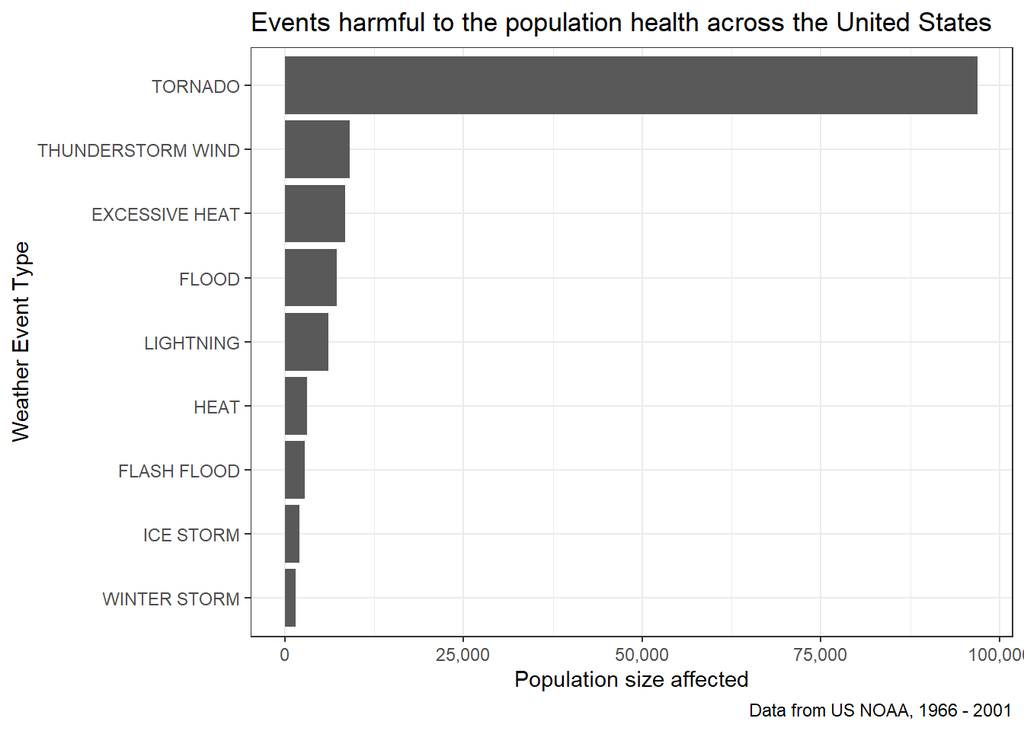

```r
# Clean data
question_one$EVTYPE <- case_when(
  question_one$EVTYPE == 'TSTM WIND' ~ 'THUNDERSTORM WIND',
  TRUE ~ question_one$EVTYPE
)

# Sum quantities of observations with the same EVTYPE
question_one <- question_one %>%
  group_by(EVTYPE) %>%
  summarize(Population_Affected = sum(Population_Affected)) %>%
  ungroup() %>%
  arrange(desc(Population_Affected))


# Graph results
question_one %>%
  ggplot(aes(x = reorder(EVTYPE, Population_Affected), y = Population_Affected)) +
  geom_bar(stat = 'identity') +
  scale_y_continuous(labels = scales::comma) +
  labs(
    x = 'Weather Event Type',
    y = 'Population size affected',
    title = 'Events harmful to the population health across the United States',
    caption = 'Data from US NOAA, 1966 - 2001'
  ) +
  coord_flip()
```

**2. Across the United States, which types of events have the greatest economic consequences?**